# Zillow API and House value estimation

Yuxi Wang

January, 2019

# About this project

In this project, an approach of estimating the value of a property was conducted by using Zillow API and sample address in Log Angeles, CA. Data were analyzed through both sequential fitting/predicting and parallel fitting/predicting. Result showed there the prediction errors from both methods were roughly the same.

# API-Application Program Interface

For this project `ZillowR` package and the Zillow API were used. Zillow is a real estate website that allows people to view homes that might be for sale (or aren’t) and gives them things like an estimated price for the house. A Zillow API account and account key (zws_id) were obtained through registering on zillow.com.

```r
library("tidyverse")
library("ZillowR")
library("XML")
library("data.table")
library("randomForest")
library("parallel")
library("microbenchmark")
```

There is a list of addresses for the city of Los Angeles available on data.gov. After reading the file of city list, and modifying, the only column with full address names was saved as `addressLA`.

```r
#read csv file-list of address in LA from web, and get the address list
   cityListLA<-read_csv(url("https://data.lacity.org/api/views/4ca8-mxuh/rows.csv?accessType=DOWNLOAD"))
#select address related columns only, and generate a new var of full address
   addressLA<-unite(cityListLA, "Address",c(HSE_NBR,HSE_DIR_CD,STR_NM,STR_SFX_CD),sep=" ") %>%
              select(Address)
   addressLA
```

```
## # A tibble: 1,000,693 x 1
##    Address
##    <chr>
##  1 14707 W SUNNY DR
##  2 16057 W COLUMBUS LANE
##  3 16068 W COUSTEAU LANE
##  4 1027 W MIGNONETTE ST
##  5 16058 W COOK LANE
##  6 2931 N DENBY AVE
##  7 11011 N GLENOAKS BLVD
##  8 13541 W VAN NUYS BLVD
##  9 13535 W VAN NUYS BLVD
## 10 16048 W COLUMBUS LANE
## # ... with 1,000,683 more rows
```

# Pull data from an API and convert that data to an appropriate form

First, a subset of these addresses was taken. Set n=4000 as sample size.

```r
set.seed(50)
n<-4000 #sample size
#randomly sample address
sampleAddress<-addressLA[sample(1:nrow(addressLA), size = n),]
```

Then data from zillow’s API with sample address was obtained by creating a user-defined function:

```r
###Integrated function for querying and formating of the data
##create a function to read zillow API based on Address, Address in n*1 data.frame
APIReadOutput<-function(Address){
  #Step 1 read API data based on Address
  #Create a function to retrieve data$response for sample address
  #zillow zws_id is hidden
  readData<-function(Address){
    GetDeepSearchResults(address = Address,citystatezip = "Los Angeles, CA",
                         zws_id = "X1-ZWz1gsug2....._7..1.")$response
  }
  #apply to all sample address
  getResponse<-lapply(unlist(Address),readData)
  #eliminate any records returned NULL for $response, this is API data XMLnode
  LADatasample<-getResponse[-(which(sapply(getResponse,is.null),arr.ind=TRUE))]

  #Step 2 get variable values for the variables
  #write a function to get all values and create a df
  readValues<-function(x){ #x for every API data XMLnode
    #prasing XML to the root node "result"
    a<-xmlToDataFrame(nodes = getNodeSet(x, "//result"))
    #prasing XML to the root node "address",still need info of street,zipcode, and city
    b<-xmlToDataFrame(nodes = getNodeSet(x, "//address"))
    #zestimate amount (our response variable) in USD
    zestimateROOT<-getNodeSet(x, "//zestimate")[[1]] # display root node of "zestimate"
    zestimate<-xmlValue(xmlChildren(zestimateROOT)[[1]]) # Value of first node amount
    #region name and type
    regionROOT<-getNodeSet(x, "//region")[[1]]
    c("Address"=b[1],"Zipcode"=b[2],"City"=b[3],"useCode"=a[5],"taxAsmtYear"=a[6],"taxAsmtValue"= a[7],
      "yearBuilt"=a[8],"lotSize"=a[9],"finishedSqFt"=a[10],"Bath"=a[11],"Bed"=a[12],"zestiAmount"=zestimate,
      "regionName"= xmlGetAttr(regionROOT,name="name"),"regionType"=xmlGetAttr(regionROOT,name="type"))
  }
  #provide lapply with a function with tryCatch to allow procession even meets an error
  lapply_with_error <- function(X,FUN,...){
    lapply(X, function(x, ...) tryCatch(FUN(x, ...),
                                        error=function(e) NULL))}
  valuesList<-lapply_with_error(LADatasample,readValues) #to retrieve values of required variables
  xx<-valuesList[-which(sapply(valuesList, is.null),arr.ind=TRUE)] #to eliminate Null element
  #since some results don't have all 14 variables generated, function to see if the list element has 14 variables
  is.14<-function(list,...){
    if (length(attributes(list)$names)==14){return(TRUE)}
    else{return(FALSE)}
  }
  #generate conditional index of whether the element has all required 14 variables
  cond<-sapply(xx,is.14)

  #Step 3 obtained data list to data frame
  #convert each element in the list to data frame, but xxx is still a list
  xxx<-lapply(xx[cond],as.data.frame)
  #convert list to data frame
  dfValues<-rbindlist(xxx)
  #modify the classification of variables, and reset the coloumn names
  dfValues<-dfValues %>% as.tibble() %>% mutate_at(c(1:3,6:13),as.character)%>%
    mutate_at(c(6:12),as.numeric) %>% filter(.[7] <= 2018)
  colnames(dfValues) <-c("Address","Zipcode","City","useCode","taxAsmtYear","taxAsmtValue",
                         "yearBuilt","lotSize","finishedSqFt","Bath", "Bed", "zestiAmount",
                         "regionName","regionType")

  #Step 4 output dataframe with eliminating any NAs in any cell
  dfValues<-na.omit(dfValues)
  return(dfValues)
}
```

In this function since not all of these addresses worked (either the address doesn’t seem to exist or zillow just doesn’t have adequate information on specific addresses), so the function includes eliminating results returned NULL several times.

Then self-defined function was applied to the sample address list to return a data frame, and it was saved to a csv file:

```r
dfZillow<-APIReadOutput(sampleAddress)
dfZillow
#write to a csv file
write_csv(dfZillow,'zillowAPIdata.csv')
```

# Fit models using parallel computing

[output not shown]

[output cut: 23 more lines]

A training set with 80% of API data and a test set with 20% were formed.

```r
set.seed(1)
train <- sample(1:nrow(dfZillow), size = nrow(dfZillow)*0.8)
test <- dplyr::setdiff(1:nrow(dfZillow), train)
dfZillowTrain <- dfZillow[train, ]
dfZillowTest <- dfZillow[test, ]
```

Since any missing data were eliminated in the reading process, it is ready to be analyzed. Bagged regression trees to predict the Zestimate were fitted and the prediction was made using test data. The variables used for fitting model are: `tax assessment value`, `year built`, `lot size`, `finished square feet`, `number of bathrooms`, and `number of bedrooms`.

First, single bagged regression trees with 2000 bootstrap replicants were fitted. The prediction errors for test data was calculated:

```r
bagFit <- randomForest::randomForest(zestiAmount ~ taxAsmtValue+yearBuilt+lotSize+finishedSqFt+ Bath+Bed, data = dfZillowTrain, mtry = 7, ntree = 2000, importance = TRUE)
bagPred <- predict(bagFit, newdata = dplyr::select(dfZillowTest, useCode,taxAsmtValue,
                                                     yearBuilt,lotSize,finishedSqFt,Bath,Bed))
bagRMSE <- sqrt(mean((bagPred-dfZillowTest$zestiAmount)^2))
```

Second, parallel computing was processed. First a function was defined for parallel computing, and 4 of my computer cores were used to do the parallel fitting and computing:

```r
#function parallel computing
parallel.bagFit<-function(data,i){
        dfZillowTrain <- data[train, ] #train is already saved outside of function
        dfZillowTest <- data[test, ]  #test is already saved outside of function
        bagFit <- randomForest::randomForest(zestiAmount ~ taxAsmtValue+yearBuilt+lotSize+finishedSqFt+ Bath+Bed,
                                             data = dfZillowTrain, mtry = 7, ntree = i, importance = TRUE)
        bagPred <- predict(bagFit, newdata = dplyr::select(dfZillowTest, useCode,taxAsmtValue,
                                                           yearBuilt,lotSize,finishedSqFt,Bath,Bed))
        bagRMSE <- sqrt(mean((bagPred-dfZillowTest$zestiAmount)^2))
        return(bagPred)
      }

#number of computer cores
      detectCores() # mine have 8
```

```
## [1] 4
```

```r
      #set # of cores to use
      cores<-4
      cluster<-makeCluster(cores)
      #export outside variables to the other R processes in the cluster
      clusterExport(cl=cluster, varlist=c("train", "test"))

 para.prediction<-parLapply(cluster,X=rep(500,cores),fun = parallel.bagFit, data=dfZillow)
 #to integrate all four prediction results by averaging them
 df.prediction<-do.call("cbind", para.prediction)
 AvgPrediction<-rowMeans(df.prediction)
 par.bagRMSE <-sqrt(mean((AvgPrediction-dfZillowTest$zestiAmount)^2))

 c("sequential.RMSE"=bagRMSE,"parallel.RMSE"=par.bagRMSE)
```

```
## sequential.RMSE   parallel.RMSE
##        813547.0        816268.3
```

In the plot, it showed how model fit, with comparing zestiAmount from test data and predicting data. Black is for sequential fit and red is for parallel fit. The reference line in blue is with intercept 0 and slope 1.

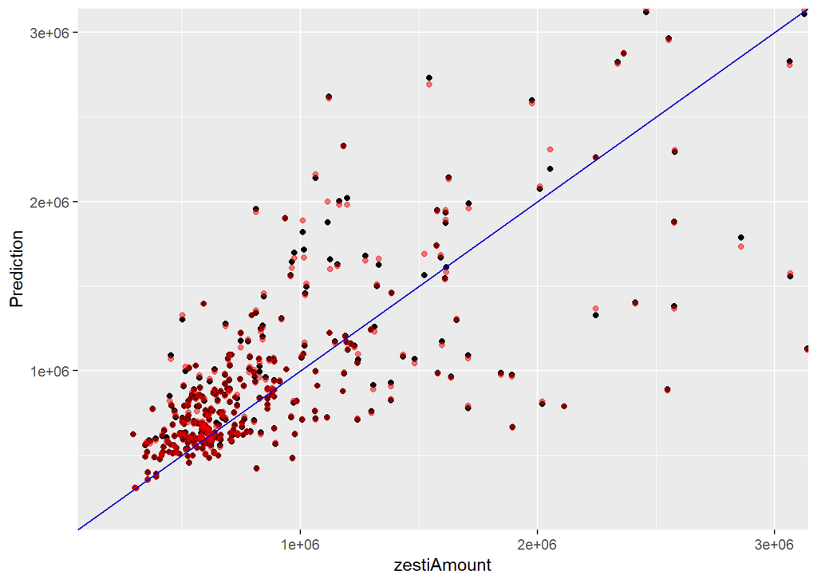

```r
x<-as.data.frame(cbind("zestiAmount"=dfZillowTest$zestiAmount,"seq"=bagPred,"par"=AvgPrediction))
ggplot(x,aes(x=zestiAmount,y=seq))+geom_jitter()+geom_jitter(aes(y=par),col="red2",alpha=0.5)+coord_cartesian(xlim=c(200000,3000000),ylim=c(200000,3000000))+geom_abline(slope = 1,intercept = 0,col="blue3")+ylab("Prediction")
```

```r
parTime<-microbenchmark({
        para.prediction<-parLapply(cluster,X=rep(500,cores),fun = parallel.bagFit, data=dfZillow)
        df.prediction<-do.call("cbind", para.prediction)
        AvgPrediction<-rowMeans(df.prediction)
        par.bagRMSE <-sqrt(mean((AvgPrediction-dfZillowTest$zestiAmount)^2))
      },times=10,unit="s")

straightTime<-microbenchmark({
       bagFit <- randomForest::randomForest(zestiAmount ~ taxAsmtValue+yearBuilt+lotSize+finishedSqFt+ Bath+Bed,
                                            data = dfZillowTrain, mtry = 7, ntree = 2000, importance = TRUE)
       bagPred <- predict(bagFit, newdata = dplyr::select(dfZillowTest, useCode,taxAsmtValue,
                                                     yearBuilt,lotSize,finishedSqFt,Bath,Bed))
       bagRMSE <- sqrt(mean((bagPred-dfZillowTest$zestiAmount)^2))
      },times=10,unit="s")
 parTime
```

```
## Unit: seconds
##                                                                                                                                                                                                                                                                                                 expr
##  {     para.prediction <- parLapply(cluster, X = rep(500, cores),          fun = parallel.bagFit, data = dfZillow)     df.prediction <- do.call("cbind", para.prediction)     AvgPrediction <- rowMeans(df.prediction)     par.bagRMSE <- sqrt(mean((AvgPrediction - dfZillowTest$zestiAmount)^2)) }
##       min       lq     mean   median      uq      max neval
##  7.846227 7.856745 7.901224 7.897845 7.93634 7.968511    10
```

```r
 straightTime
```

```
## Unit: seconds
##                                                                                                                                                                                                                                                                                                          …
##  {     bagFit <- randomForest::randomForest(zestiAmount ~ taxAsmtValue +          yearBuilt + lotSize + finishedSqFt + Bath + Bed, data = dfZillowTrain,          mtry = 7, ntree = 2000, importance = TRUE)     bagPred <- predict(bagFit, newdata = dplyr::select(dfZillowTest,          useCode, taxAs…
##       min       lq     mean   median       uq      max neval
##  19.54268 19.93899 20.85941 19.99295 21.86352 23.33244    10
```